# MLE ane MM Deliverable MM Part(Height)

Dong Chen

10-26

# 1 Introduction

Maximum likelihood (MLE) and method of moments (MM) are two common methods for constructing a model.

# 2 Background

I will explain to the reader how one might use MLE and MM to model (a) Glycohemoglobin and (b) Height of adult females. The data will be from National Health and Nutrition Examination Survey 2009-2010 (NHANES), available from the Hmisc package. I will compare and contrast the two methods in addition to comparing and contrasting the choice of underlying distribution.

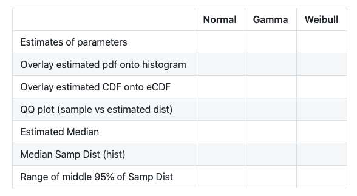

# 3 Method

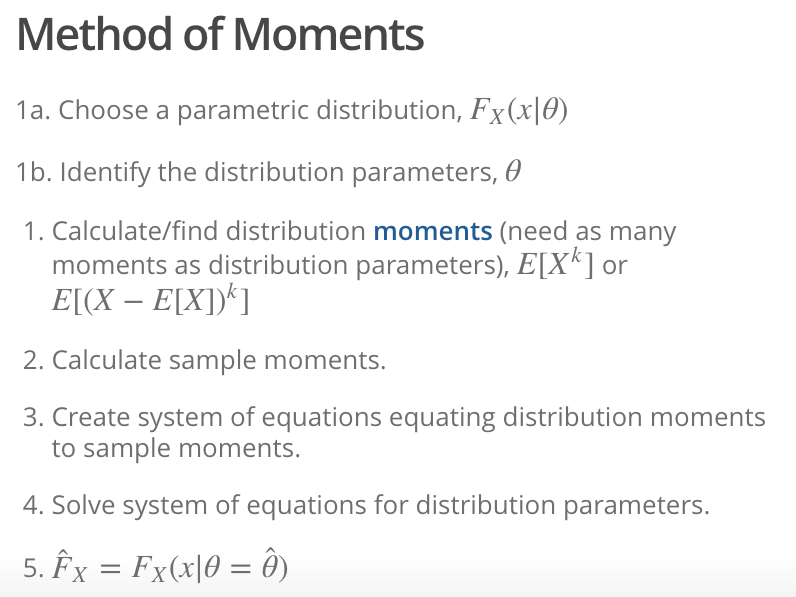

## 3.1 Data

```r
#Import data
require(dplyr)
Hmisc::getHdata(nhgh)
d1 <- nhgh %>%
  filter(sex == "female") %>%
  filter(age >= 18) %>%
  select(gh, ht) %>%
  filter(1:n()<=1000)
```

## 3.2 Normal

### 3.2.1 Estimates of parameters

According to the feature of normal distribution.`E[X]=mean(sample)` and `V[X]= Var(sample)`. Thus, we can conclude two parameters below.

```r
mm.mean=mean(d1$ht)
mm.sd=sd(d1$ht)
```

### 3.2.2 Overlay estimated pdf onto histogram

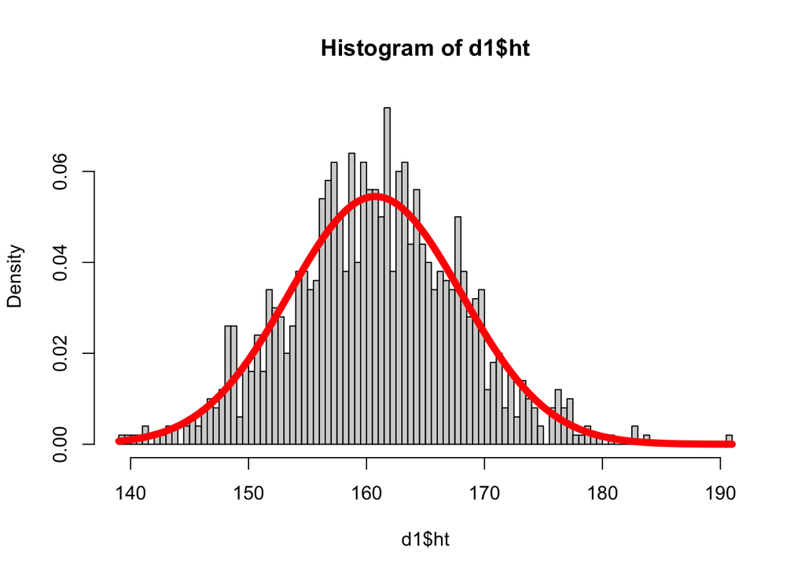

```r
hist(d1$ht,breaks = 100,freq = F)
curve(dnorm(x,mm.mean,mm.sd),col="red",lwd=6,add=T)
```

The figure above is that overlay estimated pdf onto histogram of the empirical distribution.

### 3.2.3 Overlay estimated CDF onto eCDF

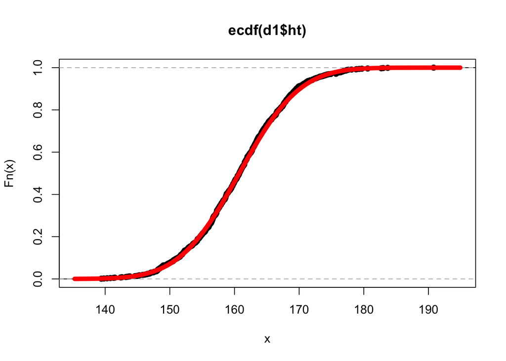

```r
plot(ecdf(d1$ht))
curve(pnorm(x,mm.mean,mm.sd),col="red",lwd=6,add=T)
```

The figure above is that overlay estimated CDF onto eCDF of the empirical distribution.

### 3.2.4 QQ plot (sample vs estimated dist)

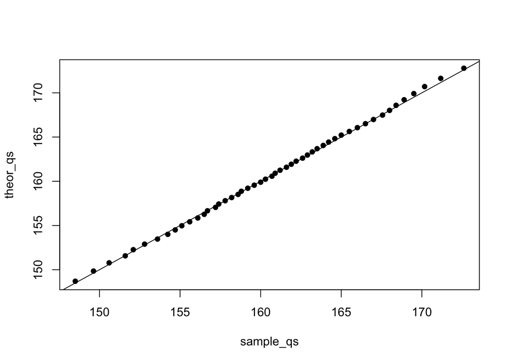

```r
qs <- seq(0.05,0.95,length=50)
sample_qs <- quantile(d1$ht,qs)
theor_qs <- qnorm(qs,mm.mean,mm.sd)
plot(sample_qs,theor_qs,pch=16)
abline(0,1)
```

Sample max fits a straight line with y=x. We can say that the sample quantile fits the theoretical quantile.

### 3.2.5 Estimated Median

```r
qnorm(0.5,mean=mm.mean,sd=mm.sd)
```

```
## [1] 160.7419
```

The estimated Median is 160.7419. We use `qnorm` to select 50% of the observations, 50% of the observations are less than it, and 50% of the observations are greater than it. So this is the median of the sample.

### 3.2.6 Median Samp Dist (hist)

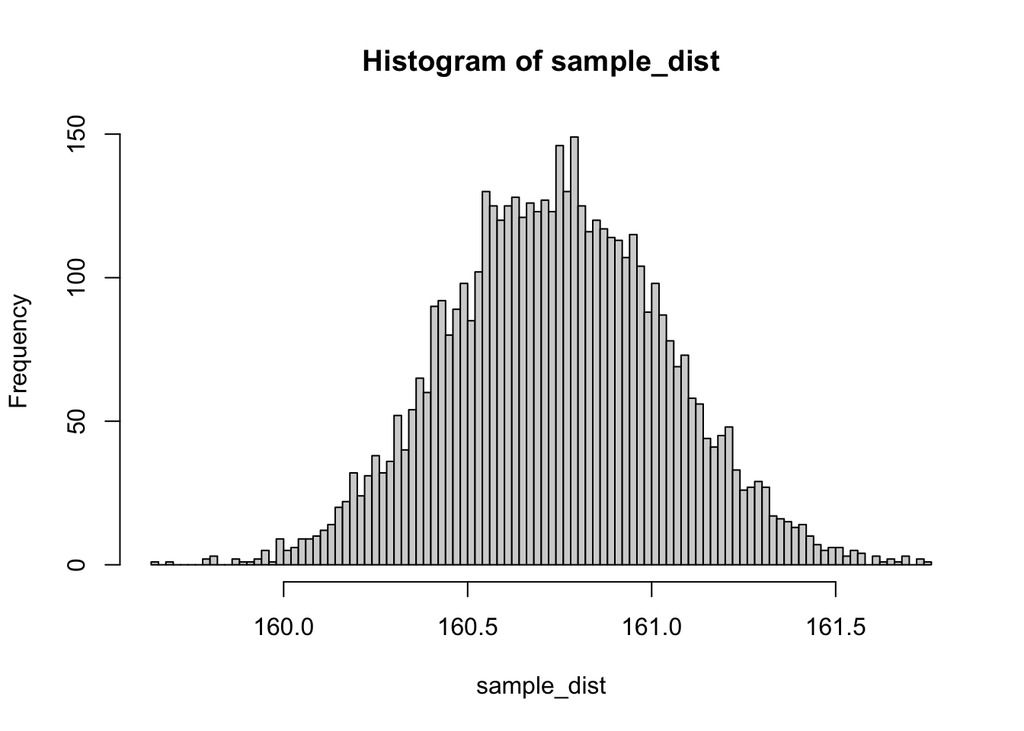

```r
M <- 5000
N <- 1000
out <- rnorm(M*N,mean=mm.mean,sd=mm.sd) %>% array( dim=c(M,N))
sample_dist <- apply(out,1,median)
hist(sample_dist, breaks = 100)
```

The figure above is that median Samp Dist (hist). We simulated 5000 experiments, each with 1000 observations, so we take the median of these 5000 experiments. Draw as histogram.

### 3.2.7 Range of middle 95% of Samp Dist

```r
quantile(sample_dist,c(0.05/2, 1 - 0.05/2))
```

```
##     2.5%    97.5%
## 160.1727 161.3306
```

The Range of middle 95% of Samp Dist is from 160.1727024 to 161.3306255. This is the 95% confidence interval. We have 95% confidence that median will be within this range. This has an indicator effect on statistical inference.

# 4 Gamma

### 4.0.1 Estimates of parameters

```r
mm_shape_gamma=mean(d1$ht)^2/var(d1$ht)
mm_scale_gamma=var(d1$ht)/mean(d1$ht)
```

### 4.0.2 Overlay estimated pdf onto histogram

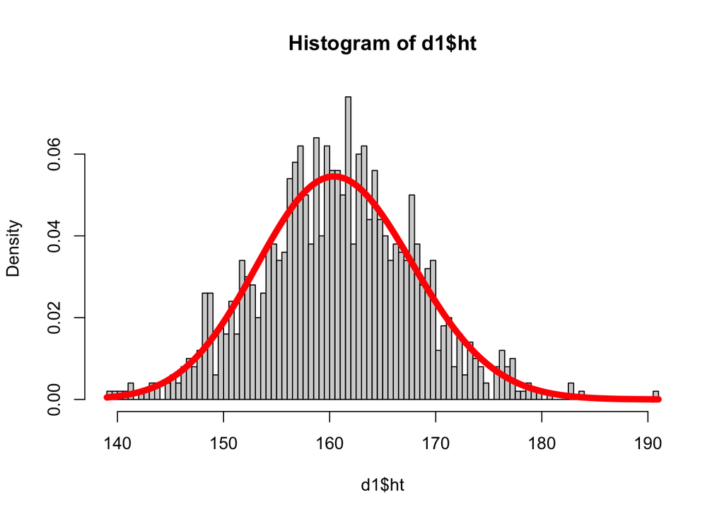

```r
hist(d1$ht,breaks = 100,freq = F)
curve(dgamma(x,shape=mm_shape_gamma,scale=mm_scale_gamma),col="red",lwd=6,add=T)
```

The figure above is that overlay estimated pdf onto histogram of the empirical distribution.

### 4.0.3 Overlay estimated CDF onto eCDF

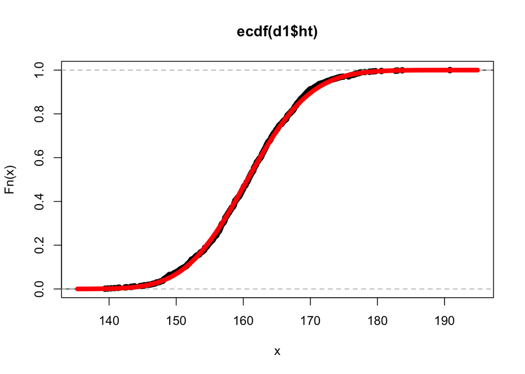

```r
plot(ecdf(d1$ht))
curve(pgamma(x,shape=mm_shape_gamma,scale=mm_scale_gamma),col="red",lwd=6,add=T)
```

The figure above is that overlay estimated CDF onto eCDF of the empirical distribution.

### 4.0.4 QQ plot (sample vs estimated dist)

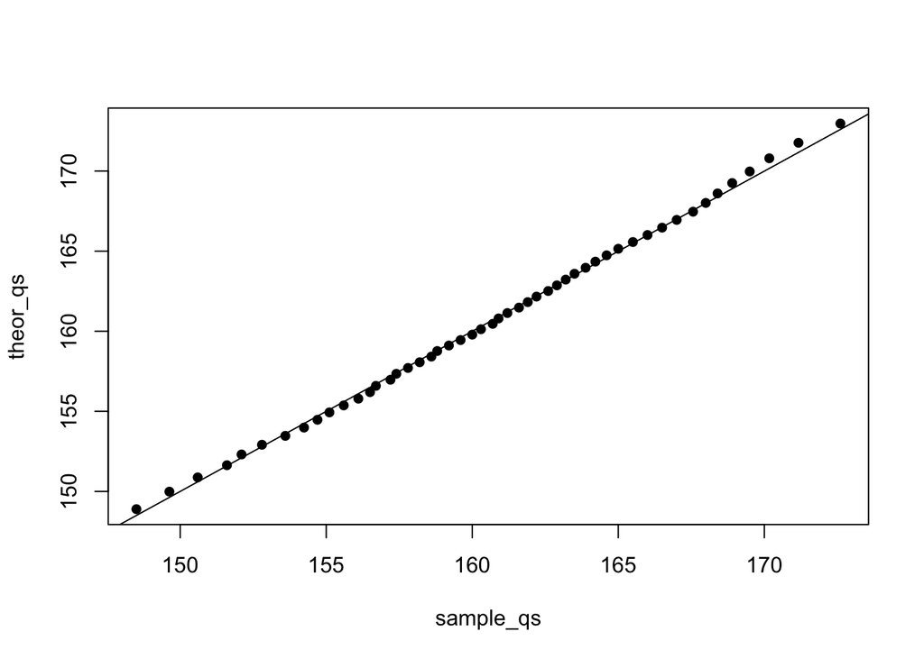

```r
qs <- seq(0.05,0.95,length=50)
sample_qs <- quantile(d1$ht,qs)
theor_qs <- qgamma(qs,shape=mm_shape_gamma,scale=mm_scale_gamma)
plot(sample_qs,theor_qs,pch=16)
abline(0,1)
```

Sample max fits a straight line with y=x. We can say that the sample quantile fits the theoretical quantile.

### 4.0.5 Estimated Median

```r
qgamma(0.5,shape=mm_shape_gamma,scale=mm_scale_gamma)
```

```
## [1] 160.6308
```

The estimated Median is 160.630794. We use `qgamma` to select 50% of the observations, 50% of the observations are less than it, and 50% of the observations are greater than it. So this is the median of the sample.

### 4.0.6 Median Samp Dist (hist)

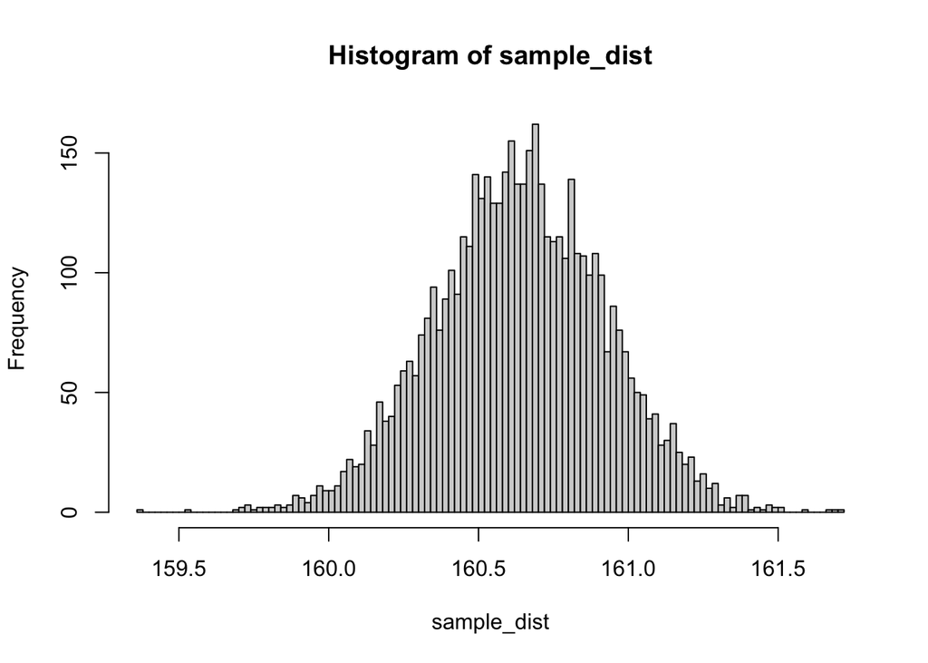

```r
M <- 5000
N <- 1000
out <- rgamma(M*N,shape=mm_shape_gamma,scale=mm_scale_gamma) %>% array( dim=c(M,N))
sample_dist <- apply(out,1,median)
hist(sample_dist, breaks = 100)
```

The figure above is that median Samp Dist (hist). We simulated 5000 experiments, each with 1000 observations, so we take the median of these 5000 experiments. Draw as histogram.

### 4.0.7 Range of middle 95% of Samp Dist

```r
quantile(sample_dist,c(0.05/2, 1 - 0.05/2))
```

```
##     2.5%    97.5%
## 160.0772 161.1870
```

The Range of middle 95% of Samp Dist is from 160.0771537 to 161.1870318. This is the 95% confidence interval. We have 95% confidence that median will be within this range. This has an indicator effect on statistical inference.

# 5 Weibull

### 5.0.1 Estimates of parameters

According to the feature of Weibull distribution.`E[X]= E(X) = b Γ(1 + 1/a)` and `V[X]=b^2 * (Γ(1 + 2/a) - (Γ(1 + 1/a))^2)`. These are not very good representations, we constructed the following equation.

```r
#Define mean of Weibull Distribution
mean.weib = function(lambda,k){
  lambda*gamma(1+1/k)
}

#Define variance of Weibull Distribution
var.weib = function(lambda,k){
  lambda^2*(gamma(1+2/k)-(gamma(1+1/k))^2)
}

#Define lambda
lambda = function(samp_mean,k){
  samp_mean/gamma(1+1/k)
}

#Define mean of Weibull Distribution using sample mean
var.weib = function(samp_mean,k){
  lambda(samp_mean,k)^2*(gamma(1+2/k)-(gamma(1+1/k))^2)
}

#Define variance of Weibull Distribution using sample mean
var.weib = function(samp_mean,k,samp_var){
  lambda(samp_mean,k)^2*(gamma(1+2/k)-(gamma(1+1/k))^2)-samp_var
}

#Build function to calculate two parameters in Weibull Distribution
mm.opt = optimize(f = function(x){
  abs(var.weib(k=x,samp_mean = mean(d1$ht),samp_var = var(d1$ht)))
},lower=10,upper = 100)

mm.weib.k = mm.opt$min

mm.weib.lambda = lambda(samp_mean = mean(d1$ht),k=mm.weib.k)
```

```r
mm.weib.k
```

```
## [1] 27.45942
```

```r
mm.weib.lambda
```

```
## [1] 163.9807
```

This is the specific value of the two parameters.

### 5.0.2 Overlay estimated pdf onto histogram

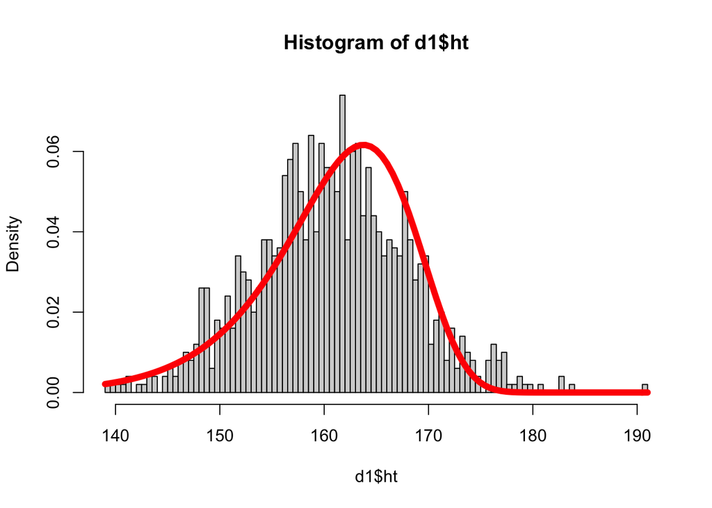

```r
hist(d1$ht,breaks = 100,freq = F)
curve(dweibull(x,shape=mm.weib.k,scale=mm.weib.lambda),col="red",lwd=6,add=T)
```

The figure above is that overlay estimated pdf onto histogram of the empirical distribution.

### 5.0.3 Overlay estimated CDF onto eCDF

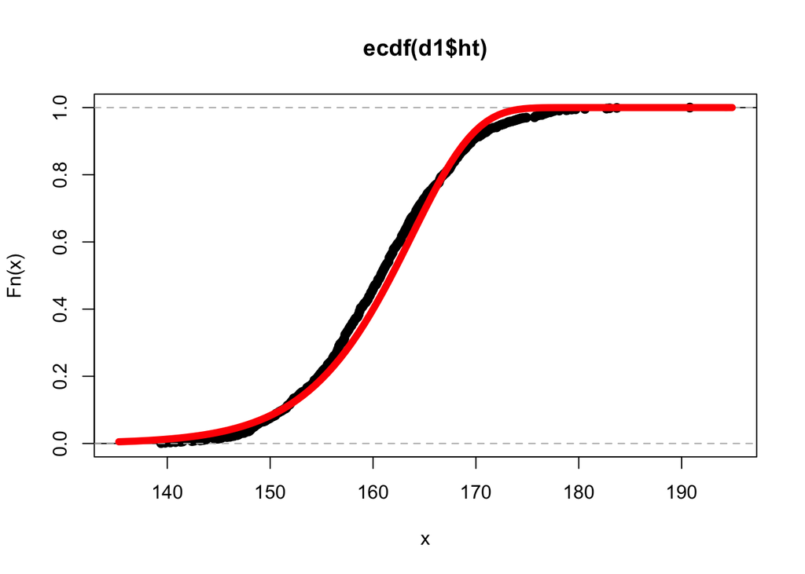

```r
plot(ecdf(d1$ht))
curve(pweibull(x,shape=mm.weib.k,scale=mm.weib.lambda),col="red",lwd=6,add=T)
```

The figure above is that overlay estimated CDF onto eCDF of the empirical distribution.

### 5.0.4 QQ plot (sample vs estimated dist)

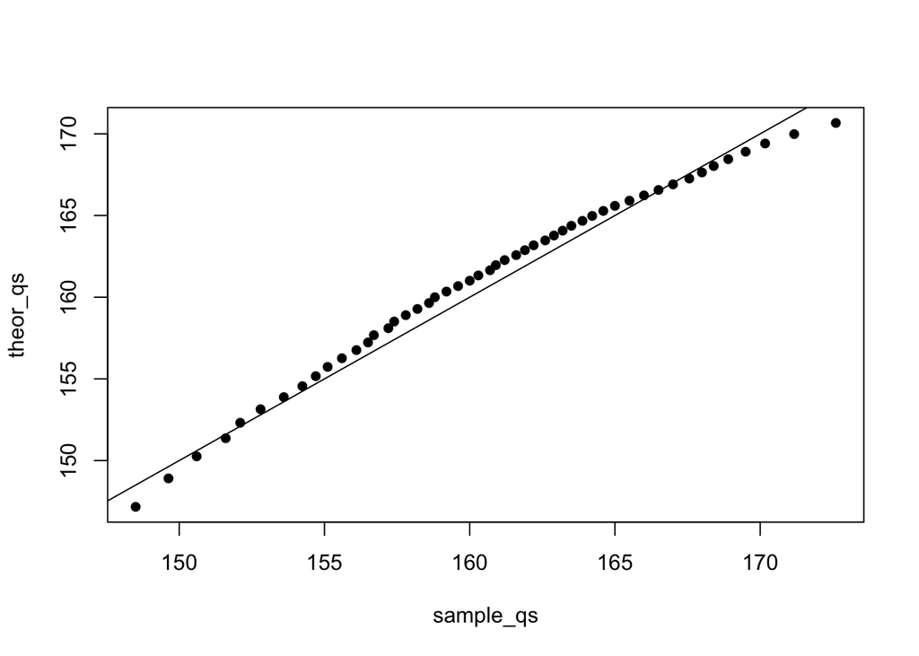

```r
qs <- seq(0.05,0.95,length=50)
sample_qs <- quantile(d1$ht,qs)
theor_qs <- qweibull(qs,shape=mm.weib.k,scale=mm.weib.lambda)
plot(sample_qs,theor_qs,pch=16)
abline(0,1)
```

Sample max doesn’t fit a straight line with y=x perfectly. We maynot say that the sample quantile fits the theoretical quantile very well in the figure.

### 5.0.5 Estimated Median

```r
qweibull(0.5,shape=mm.weib.k,scale=mm.weib.lambda)
```

```
## [1] 161.8065
```

The estimated Median is 161.8065244. We use `qweibull` to select 50% of the observations, 50% of the observations are less than it, and 50% of the observations are greater than it. So this is the median of the sample.

### 5.0.6 Median Samp Dist (hist)

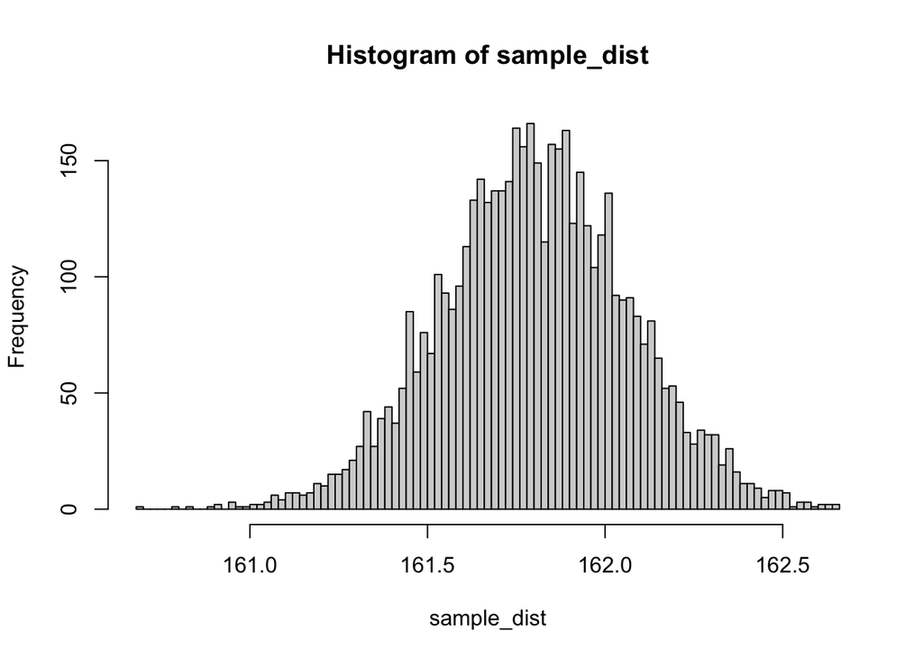

```r
M <- 5000
N <- 1000
out <- rweibull(M*N,shape=mm.weib.k,scale=mm.weib.lambda) %>% array( dim=c(M,N))
sample_dist <- apply(out,1,median)
hist(sample_dist, breaks = 100)
```

The figure above is that median Samp Dist (hist). We simulated 5000 experiments, each with 1000 observations, so we take the median of these 5000 experiments. Draw as histogram.

### 5.0.7 Range of middle 95% of Samp Dist

```r
#hist(sample_dist, breaks = 100)
quantile(sample_dist,c(0.05/2, 1 - 0.05/2))
```

```
##     2.5%    97.5%
## 161.2821 162.3276
```

```r
#abline(v = quantile(sample_dist,c(0.05/2, 1 - 0.05/2)), col = "blue", lty = 2)
```

The Range of middle 95% of Samp Dist is from 161.2821117 to 162.3275785. This is the 95% confidence interval. We have 95% confidence that median will be within this range. This has an indicator effect on statistical inference.

# 6 Conclusion

In this part, we use MM to model Height of adult females and we use three different distributions. The content above answers questions in Background part.